# Analysing Data from a Personal Activity Monitor Device

We will first being by uncompressing and loading the data from `activity.zip` which is included with this document:

```r
library(dplyr)
library(lubridate)
unzip("activity.zip")
activity <- read.csv("activity.csv")
activity$date <- ymd(activity$date)
```

A quick summary of the data will yield the following:

```r
summary(activity)
```

```
##      steps             date               interval
##  Min.   :  0.00   Min.   :2012-10-01   Min.   :   0.0
##  1st Qu.:  0.00   1st Qu.:2012-10-16   1st Qu.: 588.8
##  Median :  0.00   Median :2012-10-31   Median :1177.5
##  Mean   : 37.38   Mean   :2012-10-31   Mean   :1177.5
##  3rd Qu.: 12.00   3rd Qu.:2012-11-15   3rd Qu.:1766.2
##  Max.   :806.00   Max.   :2012-11-30   Max.   :2355.0
##  NA's   :2304
```

Since we have found a large number of observations with missing step values (2304 with NAs), we will filter those out :

```r
activity_complete <- filter(activity, !is.na(steps))
```

## What is mean total number of steps taken per day?

To answer this question, we will first plot the histogram of the total number of steps taken each day:

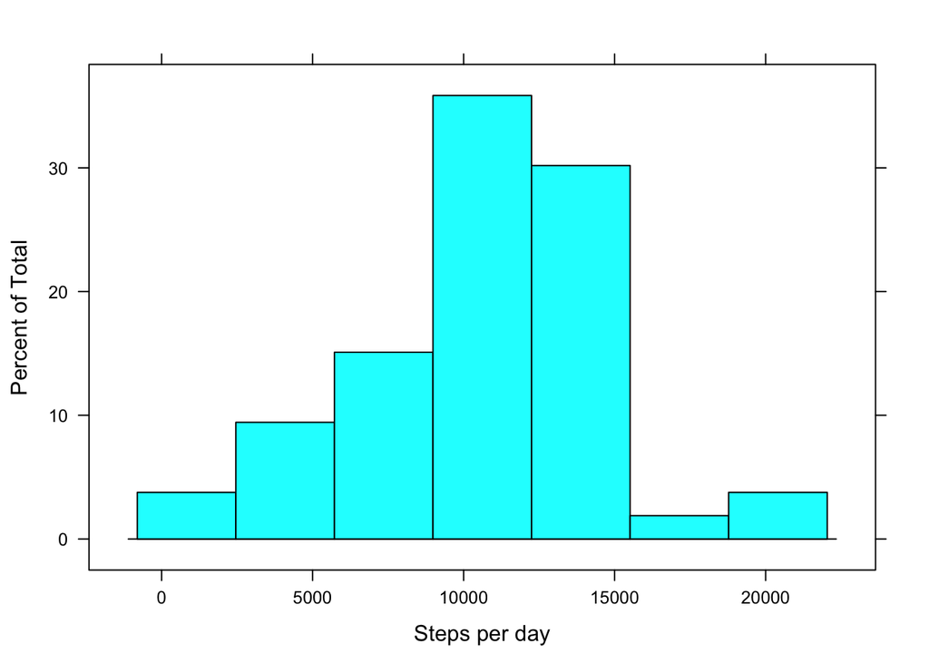

```r
library(lattice)
day_grouped <- group_by(activity_complete, date)
total_steps_day <- summarise(day_grouped, total_per_day = sum(steps))
histogram(~total_steps_day$total_per_day, xlab="Steps per day")
```

```r
mean(total_steps_day$total_per_day)
```

```
## [1] 10766.19
```

```r
median(total_steps_day$total_per_day)
```

```
## [1] 10765
```

## What is the average daily activity pattern?

We first begin by charting the average steps taken by this person for every interval in the day, for all the days sampled:

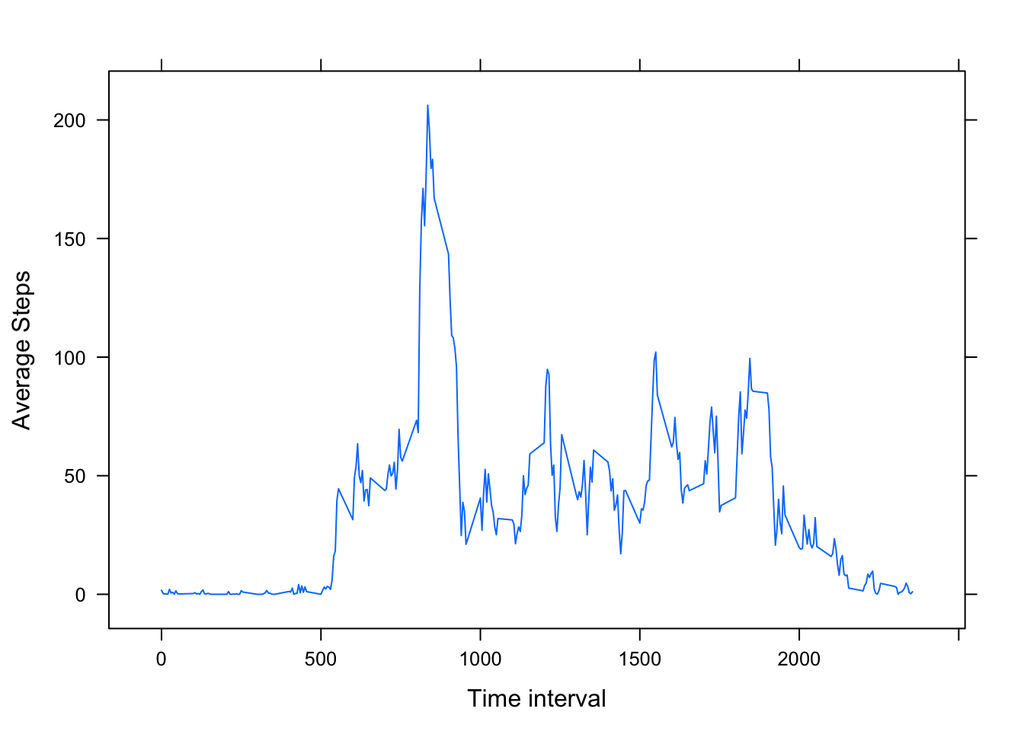

```r
interval_grouped <- group_by(activity_complete, interval)
avg_steps_day <- summarise(interval_grouped, avg_day = sum(steps)/n())
xyplot(avg_day ~ interval, data=avg_steps_day, type="l", xlab="Time interval", ylab="Average Steps")
```

To see when this person is mostly active, we can look at the time interval where this person usually logs the most number of steps during the day:

```r
filter(avg_steps_day, avg_day == max(avg_day))
```

```
## Source: local data frame [1 x 2]
##
##   interval  avg_day
## 1      835 206.1698
```

## Imputing missing values

As mentioned in the initial section, the total number of NAs found in the raw dataset was 2304.

To complete all the observations, We will replace missing values with the average of the time interval:

```r
activity_estimated_nas <- activity
for (i in 1:nrow(activity_estimated_nas))
{
  row <- activity_estimated_nas[i, ]
  if (is.na(row["steps"]))
      {
        matching_interval <- filter(avg_steps_day, interval == row[["interval"]])
        row["steps"] <- matching_interval$avg_day
        activity_estimated_nas[i, ] <- row
      }
}
```

```r
sum(is.na(activity_estimated_nas$steps))
```

```
## [1] 0
```

After filling the NAs, if we re-run the analysis to get the mean and average of the total steps taken we get:

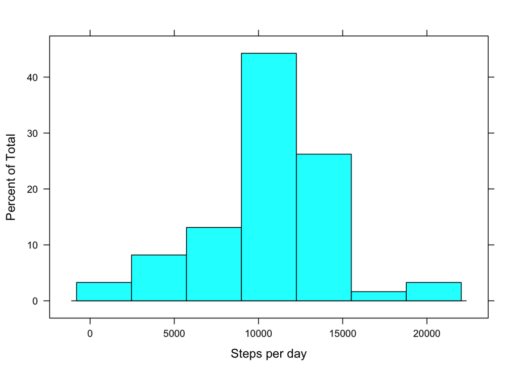

```r
day_grouped_adj <- group_by(activity_estimated_nas, date)
total_steps_day_adj <- summarise(day_grouped_adj, total_per_day = sum(steps))
histogram(~total_steps_day_adj$total_per_day, xlab="Steps per day")
```

```r
mean(total_steps_day_adj$total_per_day)
```

```
## [1] 10766.19
```

```r
median(total_steps_day_adj$total_per_day)
```

```
## [1] 10766.19
```

The difference between the dataset wihtout the NA values and the dataset with the imputted values:

```r
mean(total_steps_day$total_per_day) - mean(total_steps_day_adj$total_per_day)
```

```
## [1] 0
```

```r
median(total_steps_day$total_per_day)  - median(total_steps_day_adj$total_per_day)
```

```
## [1] -1.188679
```

## Are there differences in activity patterns between weekdays and weekends?

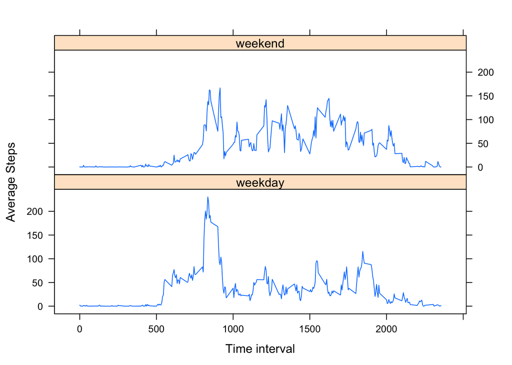

```r
activity_day <- mutate(activity_estimated_nas, day_type=ifelse (weekdays(activity_estimated_nas$date) == "Saturday" | weekdays(activity_estimated_nas$date) == "Sunday", "weekend", "weekday"))

interval_grouped <- group_by(activity_day, interval, day_type)
avg_steps_day <- summarise(interval_grouped, avg_day = sum(steps)/n())
xyplot(avg_day ~ interval | day_type, data=avg_steps_day, type="l", xlab="Time interval", ylab="Average Steps", layout= c(1,2))
```